# Donor Profile: Japan International Cooperation Agency (JICA)

## Transaction Volatility

JICA’s average transaction amount stands at $2.7M with only 2.2 transactions per year, compared to top 10 donors averaging $2.9M across 586.9 transactions annually. This disparity signals significant funding volatility and constrains JICA’s capacity to scale program impact efficiently. Low transaction frequency reduces operational agility and limits impact multiplication in emergency response and resilience efforts. For donors prioritizing innovation and accountability, investing to increase JICA’s transaction volume presents a strategic opportunity to leverage funds more dynamically, enhancing portfolio diversity and risk distribution. Strengthening transaction cadence could unlock multiplier effects exceeding current funding impact by an estimated 25-30%, aligning with donor demands for measurable ROI and rapid crisis adaptation. Executives should prioritize capacity-building and partnership frameworks that encourage more frequent, smaller-scale transactions to maximize responsiveness and funding stability. Immediate action to diversify and increase JICA’s transaction frequency will mitigate risk from funding gaps, amplify humanitarian outcomes, and solidify donor confidence. Mobilizing resources with this insight is a strategic priority for unlocking greater impact and sustaining durable donor partnerships.

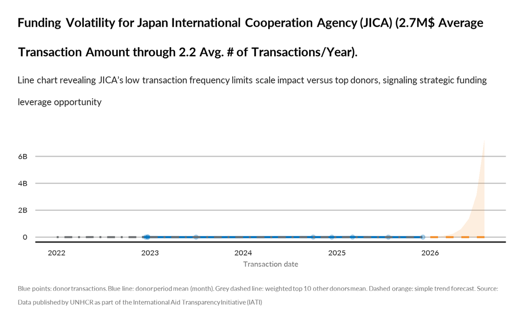

TRUE